# PUTTING IT ALL TOGETHER

NU Pathology LearnR! Fall 2020 Session 6

This report represents analyses conducted in Session 6 of the Fall 2020 NU Pathology LearnR! course. The goal is to replicate parts of Table 1 and Figure 1 from the following publication, using the associated, publicly available data set.

*Source: LONG-TERM EFFECTS OF BUDESONIDE OR NEDOCROMIL IN CHILDREN WITH ASTHMA by THE CHILDHOOD ASTHMA MANAGEMENT PROGRAM RESEARCH GROUP published in N Engl J Med 2000;343:1054-63.*

“The Childhood Asthma Management Program (CAMP) was a clinical trial carried out in children with asthma. The trial was designed to determine the long-term effects of 3 treatments (budesonide, nedocromil, or placebo) on pulmonary function as measured by normalized FEV1 over a 5-6.5 year period.”

“Conclusions: In children with mild-to-moderate asthma, neither budesonide nor nedocromil is better than placebo in terms of lung function, but inhaled budesonide improves airway responsiveness and provides better control of asthma than placebo or nedocromil. The side effects of budesonide are limited to a small, transient reduction in growth velocity.”

TABLE 1. CHARACTERISTICS OF THE PATIENTS AT BASE LINE.

[output not shown]

Figure 1. Mean Values for Spirometric Measures before and after the Use of a Bronchodilator during Four Years of Follow-up in the Budesonide (Bud), Nedocromil (Ned), and Placebo (Plbo) Groups.

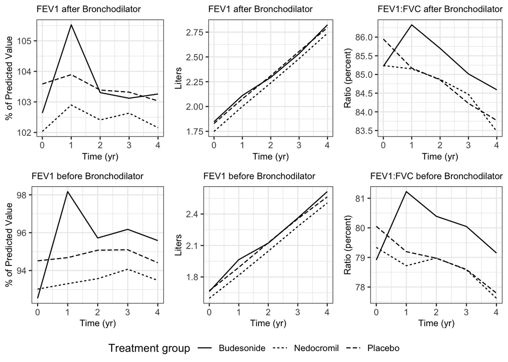